# lab3

#### Suppose you have a loaded die with a 10% chance of rolling a 1-5 and a 50% chance of rolling a 6, and assume that 99% of dice are fair.

Define the given parameters.

```r
prob_fair <- 0.99
prob_loaded <- 1 - prob_fair
roll_liklihoods_given_fair <- rep(1/6, 6)
roll_liklihoods_given_loaded <- c(rep(0.1, 5), 0.5)
```

Suppose a sample die is rolled with the following outcomes:

```r
observed_rolls <- c(2, 3, 2, 6, 3, 5, 6, 2, 6, 6, 2, 6, 6, 2, 3, 6, 6, 6, 5, 6, 6, 5, 6, 6, 6, 6, 6, 4, 6, 3, 3, 3, 6, 6, 5, 6, 6)
```

A graph showing the posterior probability that the die is loaded as a function of the number of times the die has been rolled, given the above roll outcomes.

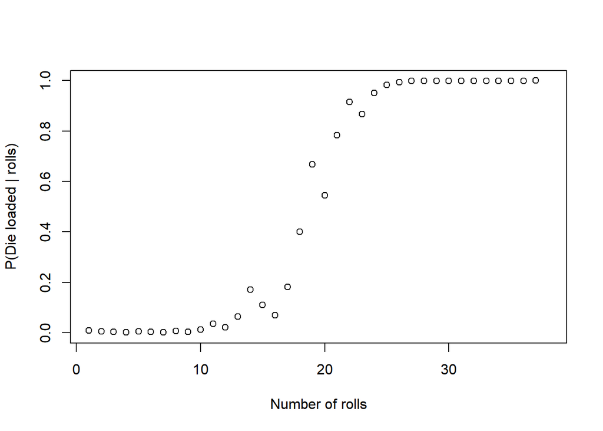

```r
loaded_probs <- vector()

for(i in 1:length(observed_rolls)) {
    loaded_probs[i] <- prob_loaded

    denom <- prob_fair * roll_liklihoods_given_fair[observed_rolls[i]] + prob_loaded * roll_liklihoods_given_loaded[observed_rolls[i]]

    # Update prior beliefs
    prob_fair <- prob_fair * roll_liklihoods_given_fair[observed_rolls[i]] / denom
    prob_loaded <- prob_loaded * roll_liklihoods_given_loaded[observed_rolls[i]] / denom

}

plot(1:length(observed_rolls), loaded_probs, ylab="P(Die loaded | rolls)", xlab="Number of rolls", ylim=c(0,1), xlim=c(1, length(observed_rolls) + 1))
```

Determine the average number of loaded die rolls required to establish 99.999% confidence that the die is loaded.

Simulate a test result until a confidence threshold is met.

```r
number_trials <- 10000
confidence_cutoff <- 0.99999
rolls_required <- vector()

for (i in i:number_trials) {

  prob_fair <- 0.99
  prob_loaded <- 1 - prob_fair
  number_rolls <- 0
  while (prob_loaded < confidence_cutoff) {

    number_rolls <- number_rolls + 1

    # Simulate rolling a loaded die
    roll_result <- sample(x=1:length(roll_liklihoods_given_loaded), size=1, prob=roll_liklihoods_given_loaded)

    denom <- prob_fair * roll_liklihoods_given_fair[roll_result] + prob_loaded * roll_liklihoods_given_loaded[roll_result]

    # Update prior beliefs
    prob_fair <- prob_fair * roll_liklihoods_given_fair[roll_result] / denom
    prob_loaded <- prob_loaded * roll_liklihoods_given_loaded[roll_result] / denom

  }

    rolls_required <- c(rolls_required, number_rolls)
  }

avg_rolls <- mean(rolls_required)
```

The average number of rolls required, given a sample size of 10000, is **56**.

Define the given parameters

```r
prob_disease <- 0.01
prob_health <- 1 - prob_disease
true_positive_liklihood = 0.91
false_positive_liklihood = 1 - true_positive_liklihood
true_negative_liklihood = .84
false_negative_liklihood = 1 - true_negative_liklihood
test_price <- 1
```

Suppose a patient has the disease. To achieve the hospital’s requirement of 99.999% test result certainty, about how many times would the patient on average have to repeat the test?

Define a function for simulating tests and prior updates.

```r
get_mean_tests <- function(diseased) {
  tests_required <- vector()
  for (i in i:number_trials) {

    prob_disease <- 0.01
    prob_health <- 1 - prob_disease
    number_tests <- 0
    while (prob_disease < confidence_cutoff & prob_health < confidence_cutoff) {

      number_tests <- number_tests + 1

      # Simulate an accurate test result
      if (diseased) {
        test_result <- sample(x=1:2, size=1, prob=c(true_positive_liklihood, false_positive_liklihood))
      } else {
        test_result <- sample(x=1:2, size=1, prob=c(true_negative_liklihood, false_negative_liklihood))
      }

      denom <- prob_disease * (if (test_result==1) true_positive_liklihood else false_negative_liklihood) + prob_health * (if (test_result==1) false_positive_liklihood else true_negative_liklihood)

        # Update prior beliefs
      prob_disease <- prob_disease * (if (test_result==1) true_positive_liklihood else false_negative_liklihood) / denom
        prob_health <- prob_health * (if (test_result==1) false_positive_liklihood else true_negative_liklihood) / denom

    }

      tests_required <- c(tests_required, number_tests)
  }

  return(mean(tests_required))
}
```

Simulate tests in a diseased and healthy individual.

```r
number_trials <- 1000
confidence_cutoff <- 0.99999
avg_tests_diseased <- get_mean_tests(diseased=TRUE)
avg_tests_healthy <- get_mean_tests(diseased=FALSE)
```

On average, **8** tests are required to establish 99.999% confidence in a positive test result.  
On average, **10** tests are required to establish 99.999% confidence in a negative test result.

Suppose the hospital anticipates testing one million patients per year. What should the hospital budget for these tests?

```r
number_patients <- 1000000
yearly_cost <- number_patients * (prob_disease * avg_tests_diseased + prob_health * avg_tests_healthy) * test_price
```

The anticipated yearly cost is: **$10,055,954**.

#### Suppose another manufacturer offers an improved, but more expensive test with a true positive rate of 96% and a true negative rate of 95%.

Define the given parameters

```r
true_positive_liklihood = 0.96
false_positive_liklihood = 1 - true_positive_liklihood
true_negative_liklihood = .95
false_negative_liklihood = 1 - true_negative_liklihood
```

Determine the number of times the new test must be repeated in diseased and healthy patients to conform to the hospital’s test result confidence requirement.

```r
avg_tests_diseased <- get_mean_tests(diseased=TRUE)
avg_tests_healthy <- get_mean_tests(diseased=FALSE)
```

On average, **6** tests are required to establish 99.999% confidence in a positive test result.  
On average, **6** tests are required to establish 99.999% confidence in a negative test result.

Supposing a requirement of one test per patient, what test price would warrant using the updated test?

```r
number_patients <- 1000000
yearly_tests <- number_patients
# yearly_tests * test_price < yearly_cost (using original test)
test_price <- yearly_cost / yearly_tests
```

A test price lower than **$10.06** would be required to incentivize the hospital in switching to the new test.

Allowing as many tests as necessary to meet the hospital’s test result confidence requirement, what test price would warrant using the updated test?

```r
number_patients <- 1000000
yearly_tests <- number_patients * (prob_disease * avg_tests_diseased + prob_health * avg_tests_healthy)
test_price <- yearly_cost / yearly_tests
```

A test price lower than **$1.58** would be required to incentivize the hospital in switching to the new test.